# Statistical Programming in R: Lecture 7

Data Joins

Josemari Feliciano DATA 412/612 - American University

2024-10-22

## Note:

I will later clean this up. You might see weird symbols (e.g., “.extra-tiny[”) sporadically which I had to use for the slide version of this.

## Administrative: First midterm exam

The class did well in the first midterm, specially after I gave students 10 points by simply having a rendered HTML:

- Exam was out of 102 points.
- Highest scorers earned 102 points.
- Median is 90. Mean is 84.

I designed the first midterm to be easy: designed to enable half of the class who feel more comfortable with R to finish midterm within 1 - 1 1/2 hours. You were effectively given 3 hours to finish and submit all the files.

Among those who took the midterm, 33% of students rated the midterm as easy. The remaining 67% rated it as fair.

## Administrative: Final project

The final project is only required for graduate students. Undergraduate students may also do the final project if you want to create a data science portfolio for future jobs, etc. In that case, you’d be graded using the graduate student grading scheme.

I’ll discuss the final project in greater detail next week (e.g., format, required output, etc.).

Within the course Canvas site, please see `Final Project - Data Set Approval` under Homework which is due next week (October 30 - Wednesday at 11:59 pm). It includes a list of websites that houses large volumes of data sets.

The Data Set approval deadline (Oct 30 at 11:59pm) means you have three opportunities to attend my regular office hours to chat about your final project (e.g., brainstorm). Again, office hours are Wednesdays and Sundays via Zoom at 8:00 pm - 9:00 pm.

## Related Issue: Cancer Atlas Data from midterm

- It is possible that the data you download for your final project are not ‘clean’ or optimized for R. You might have to simplify or clean the variables or contents before loading them into R.
- Let us quickly open the `cancer_atlas.xlsx` file we used in the midterm. A copy can be found in Canvas under: **Files** > **Class Data Sets**. Let us compare the two sheets within the excel file. Let us compare the two sheets: dirty (closely resembles the actual data I downloaded) and clean (data after I cleaned variable names, etc.).

## Today’s agenda

Today’s lecture will focus on working with multiple tables.

Data Joins is covered in Chapter 19 of your textbook.

Joining verbs are part of the dplyr package, which again is a core tidyverse package.

Before we continue, download Lecture7SlidesCode.qmd from Canvas. It has a copy of all the code shared within this slide deck so you are able to run them yourself.

### Joins in R

It’s rare that a data analysis involves only a single table (data frame). Typically you have many tables (data frames), and you must join them together to answer the questions that you’re interested in.

Let us work with flights. I am choosing to load a sample from github instead of the nycflights13 package because nycflights13 is not working for one of your fellow students.

.extra-tiny[

```r
library(tidyverse)
flights <- read_rds("https://github.com/jmtfeliciano/teachingdata/raw/refs/heads/main/flights.rds")
glimpse(flights)
```

```
## Rows: 180,000
## Columns: 19
## $ year           <int> 2013, 2013, 2013, 2013, 2013, 2013, 2013, 2013, 2013, 2…
## $ month          <int> 1, 5, 11, 4, 11, 9, 9, 12, 2, 4, 9, 6, 6, 3, 9, 11, 9, …
## $ day            <int> 10, 16, 11, 24, 20, 11, 26, 19, 19, 14, 12, 9, 29, 17, …
## $ dep_time       <int> 1649, 1257, 1821, 918, 1724, 814, 1654, 1206, 1946, 154…
## $ sched_dep_time <int> 1655, 1305, 1825, 925, 1729, 815, 1655, 1130, 1900, 144…
## $ dep_delay      <dbl> -6, -8, -4, -7, -5, -1, -1, 36, 46, 62, 119, -7, -3, -2…
## $ arr_time       <int> 1958, 1436, 2108, 1238, 1923, 1041, 1837, 1414, 2209, 1…
## $ sched_arr_time <int> 2029, 1455, 2149, 1235, 1941, 1105, 1845, 1342, 2133, 1…
## $ arr_delay      <dbl> -31, -19, -41, 3, -18, -24, -8, 32, 36, 64, 109, -9, -1…
## $ carrier        <chr> "DL", "MQ", "AS", "AA", "EV", "B6", "AA", "DL", "FL", "…
## $ flight         <int> 706, 4426, 5, 1097, 3849, 183, 2223, 2219, 645, 1556, 3…
## $ tailnum        <chr> "N318NB", "N735MQ", "N423AS", "N585AA", "N13994", "N554…
## $ origin         <chr> "JFK", "LGA", "EWR", "LGA", "EWR", "JFK", "LGA", "LGA",…
## $ dest           <chr> "AUS", "CMH", "SEA", "DFW", "CVG", "MCO", "STL", "MSP",…
## $ air_time       <dbl> 221, 77, 319, 219, 90, 122, 123, 156, 122, 153, 155, 10…
## $ distance       <dbl> 1521, 479, 2402, 1389, 569, 944, 888, 1020, 762, 1068, …
## $ hour           <dbl> 16, 13, 18, 9, 17, 8, 16, 11, 19, 14, 8, 15, 17, 15, 8,…
## $ minute         <dbl> 55, 5, 25, 25, 29, 15, 55, 30, 0, 45, 15, 15, 0, 12, 30…
## $ time_hour      <dttm> 2013-01-10 16:00:00, 2013-05-16 13:00:00, 2013-11-11 1…
```

]

### flights: sample scrollable data

| year | month | day | dep_time | sched_dep_time | dep_delay | arr_time | sched_arr_time | arr_delay | carrier | flight | tailnum | origin | dest | air_time | distance | hour | minute | time_hour |
| --- | --- | --- | --- | --- | --- | --- | --- | --- | --- | --- | --- | --- | --- | --- | --- | --- | --- | --- |
| 2013 | 1 | 10 | 1649 | 1655 | -6 | 1958 | 2029 | -31 | DL | 706 | N318NB | JFK | AUS | 221 | 1521 | 16 | 55 | 2013-01-10T21:00:00Z |
| 2013 | 5 | 16 | 1257 | 1305 | -8 | 1436 | 1455 | -19 | MQ | 4426 | N735MQ | LGA | CMH | 77 | 479 | 13 | 5 | 2013-05-16T17:00:00Z |
| 2013 | 11 | 11 | 1821 | 1825 | -4 | 2108 | 2149 | -41 | AS | 5 | N423AS | EWR | SEA | 319 | 2402 | 18 | 25 | 2013-11-11T23:00:00Z |
| 2013 | 4 | 24 | 918 | 925 | -7 | 1238 | 1235 | 3 | AA | 1097 | N585AA | LGA | DFW | 219 | 1389 | 9 | 25 | 2013-04-24T13:00:00Z |
| 2013 | 11 | 20 | 1724 | 1729 | -5 | 1923 | 1941 | -18 | EV | 3849 | N13994 | EWR | CVG | 90 | 569 | 17 | 29 | 2013-11-20T22:00:00Z |

## Joins in R

One of the issues with the flights data is that it doesn’t have the carrier names. The **carrier** variable is limited to the two-digit airline symbol. But there is another table (**airlines** table) that has a similar **carrier** variable with the carrier name fully spelled out:

```r
airlines <- read_rds("https://github.com/jmtfeliciano/teachingdata/raw/refs/heads/main/airlines.rds")
head(airlines)
```

```
## # A tibble: 6 × 2
##   carrier name
##   <chr>   <chr>
## 1 9E      Endeavor Air Inc.
## 2 AA      American Airlines Inc.
## 3 AS      Alaska Airlines Inc.
## 4 B6      JetBlue Airways
## 5 DL      Delta Air Lines Inc.
## 6 EV      ExpressJet Airlines Inc.
```

## Joining the two tables

Before we can join any two tables, we need to identify a variable they have in common that we can use to join them by. This is often referred to as **join key**.

In both the flights and airlines table, both contain a **carrier** column that contain the two digit symbol. In this case, **carrier** is our **join key**.

There are many types of joins we will discuss today. But the most common one you’ll use in the real world is called `left_join()`. You may think of `left_join()` as a function/tool that augments your primary data with additional data from another table. Since this join adds columns/variables, this is often referred to as a mutating join.

If we want to include the fully spelled out airline name into the flights table, we will use `left_join()`.

## Using left_join to combine flights

.extra-tiny[

```r
combined_airline_table <- flights |>
  left_join(airlines, join_by(carrier))
  # flights is the primary table we are working with
  # using carrier as join key,
  # all variables from airlines are combined with flights

glimpse(combined_airline_table)
```

```
## Rows: 180,000
## Columns: 20
## $ year           <int> 2013, 2013, 2013, 2013, 2013, 2013, 2013, 2013, 2013, 2…
## $ month          <int> 1, 5, 11, 4, 11, 9, 9, 12, 2, 4, 9, 6, 6, 3, 9, 11, 9, …
## $ day            <int> 10, 16, 11, 24, 20, 11, 26, 19, 19, 14, 12, 9, 29, 17, …
## $ dep_time       <int> 1649, 1257, 1821, 918, 1724, 814, 1654, 1206, 1946, 154…
## $ sched_dep_time <int> 1655, 1305, 1825, 925, 1729, 815, 1655, 1130, 1900, 144…
## $ dep_delay      <dbl> -6, -8, -4, -7, -5, -1, -1, 36, 46, 62, 119, -7, -3, -2…
## $ arr_time       <int> 1958, 1436, 2108, 1238, 1923, 1041, 1837, 1414, 2209, 1…
## $ sched_arr_time <int> 2029, 1455, 2149, 1235, 1941, 1105, 1845, 1342, 2133, 1…
## $ arr_delay      <dbl> -31, -19, -41, 3, -18, -24, -8, 32, 36, 64, 109, -9, -1…
## $ carrier        <chr> "DL", "MQ", "AS", "AA", "EV", "B6", "AA", "DL", "FL", "…
## $ flight         <int> 706, 4426, 5, 1097, 3849, 183, 2223, 2219, 645, 1556, 3…
## $ tailnum        <chr> "N318NB", "N735MQ", "N423AS", "N585AA", "N13994", "N554…
## $ origin         <chr> "JFK", "LGA", "EWR", "LGA", "EWR", "JFK", "LGA", "LGA",…
## $ dest           <chr> "AUS", "CMH", "SEA", "DFW", "CVG", "MCO", "STL", "MSP",…
## $ air_time       <dbl> 221, 77, 319, 219, 90, 122, 123, 156, 122, 153, 155, 10…
## $ distance       <dbl> 1521, 479, 2402, 1389, 569, 944, 888, 1020, 762, 1068, …
## $ hour           <dbl> 16, 13, 18, 9, 17, 8, 16, 11, 19, 14, 8, 15, 17, 15, 8,…
## $ minute         <dbl> 55, 5, 25, 25, 29, 15, 55, 30, 0, 45, 15, 15, 0, 12, 30…
## $ time_hour      <dttm> 2013-01-10 16:00:00, 2013-05-16 13:00:00, 2013-11-11 1…
## $ name           <chr> "Delta Air Lines Inc.", "Envoy Air", "Alaska Airlines I…
```

]

### combined_airline_table: sample scrollable data

| year | month | day | dep_time | sched_dep_time | dep_delay | arr_time | sched_arr_time | arr_delay | carrier | flight | tailnum | origin | dest | air_time | distance | hour | minute | time_hour | name |
| --- | --- | --- | --- | --- | --- | --- | --- | --- | --- | --- | --- | --- | --- | --- | --- | --- | --- | --- | --- |
| 2013 | 1 | 10 | 1649 | 1655 | -6 | 1958 | 2029 | -31 | DL | 706 | N318NB | JFK | AUS | 221 | 1521 | 16 | 55 | 2013-01-10T21:00:00Z | Delta Air Lines Inc. |
| 2013 | 5 | 16 | 1257 | 1305 | -8 | 1436 | 1455 | -19 | MQ | 4426 | N735MQ | LGA | CMH | 77 | 479 | 13 | 5 | 2013-05-16T17:00:00Z | Envoy Air |
| 2013 | 11 | 11 | 1821 | 1825 | -4 | 2108 | 2149 | -41 | AS | 5 | N423AS | EWR | SEA | 319 | 2402 | 18 | 25 | 2013-11-11T23:00:00Z | Alaska Airlines Inc. |
| 2013 | 4 | 24 | 918 | 925 | -7 | 1238 | 1235 | 3 | AA | 1097 | N585AA | LGA | DFW | 219 | 1389 | 9 | 25 | 2013-04-24T13:00:00Z | American Airlines Inc. |
| 2013 | 11 | 20 | 1724 | 1729 | -5 | 1923 | 1941 | -18 | EV | 3849 | N13994 | EWR | CVG | 90 | 569 | 17 | 29 | 2013-11-20T22:00:00Z | ExpressJet Airlines Inc. |

## Using left_join to combine flights

These five R objects are equivalent (uses different syntax):

```r
# Your book's preferred format:
combined_table <- flights |>
  left_join(airlines, join_by(carrier))

# An alternate version of your book's preferred format:
combined_table <- flights |>
  left_join(airlines)
# without join_by(), R makes a guess that you want to use carrier

# This is equivalent
combined_table <- left_join(flights, airlines, join_by(carrier))

# This is equivalent
# This is considered 'old notation' by your book
# But most R users like me still uses this over join_by()
combined_table <- left_join(flights, airlines, by = c("carrier"))

# This is equivalent
combined_table <- left_join(flights, airlines)
```

## Preferred syntax from last page?

To me, it doesn’t matter. Pick one, then consistently use it.

This reminds me of two deviations within the R community on ggplot:

.pull-left[ .extra-tiny[

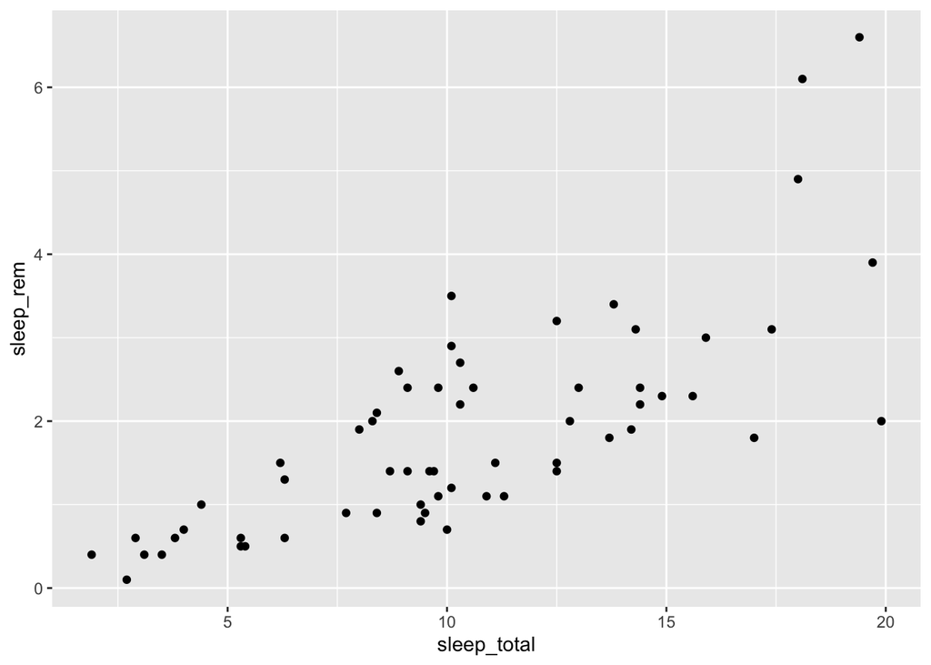

```r
# My preferred coding
msleep |>
  ggplot(mapping = aes(x = sleep_total, y = sleep_rem)) +
  geom_point()
```

] ]

.pull-right[ .extra-tiny[

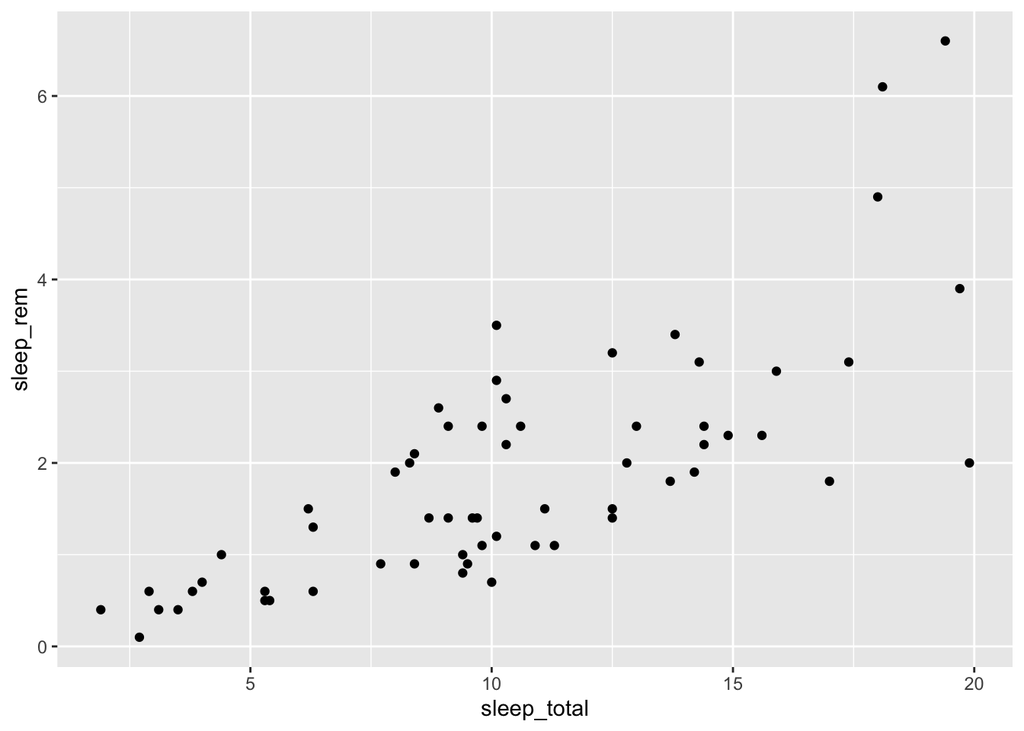

```r
# The way your book taught you
ggplot(data = msleep,
       mapping = aes(x = sleep_total, y = sleep_rem)) +
  geom_point()
```

] ]

## Let us explore all other joins

For the purpose of the next few slides, I am creating these two R objects below in the R env’t (I don’t expect you to know how to use tribble at all). Just know that two tables are created in R.

```r
superheroes <- tibble::tribble(
       ~name, ~alignment,  ~gender,          ~publisher,
   "Magneto",      "bad",   "male",            "Marvel",
     "Storm",     "good", "female",            "Marvel",
  "Mystique",      "bad", "female",            "Marvel",
    "Batman",     "good",   "male",                "DC",
     "Joker",      "bad",   "male",                "DC",
  "Catwoman",      "bad", "female",                "DC",
   "Hellboy",     "good",   "male", "Dark Horse Comics"
  )

publishers <- tibble::tribble(
  ~publisher, ~yr_founded,
        "DC",       1934,
    "Marvel",       1939,
     "Image",       1992
  )
```

## Viewing superheroes and publishers

.pull-left[

.extra-tiny[

```r
superheroes <- tibble::tribble(
       ~name, ~alignment,  ~gender,          ~publisher,
   "Magneto",      "bad",   "male",            "Marvel",
     "Storm",     "good", "female",            "Marvel",
  "Mystique",      "bad", "female",            "Marvel",
    "Batman",     "good",   "male",                "DC",
     "Joker",      "bad",   "male",                "DC",
  "Catwoman",      "bad", "female",                "DC",
   "Hellboy",     "good",   "male", "Dark Horse Comics"
  )
superheroes
```

```
## # A tibble: 7 × 4
##   name     alignment gender publisher
##   <chr>    <chr>     <chr>  <chr>
## 1 Magneto  bad       male   Marvel
## 2 Storm    good      female Marvel
## 3 Mystique bad       female Marvel
## 4 Batman   good      male   DC
## 5 Joker    bad       male   DC
## 6 Catwoman bad       female DC
## 7 Hellboy  good      male   Dark Horse Comics
```

] ]

.pull-right[ .extra-tiny[

```r
publishers <- tibble::tribble(
  ~publisher, ~yr_founded,
        "DC",       1934,
    "Marvel",       1939,
     "Image",       1992
  )
publishers
```

```
## # A tibble: 3 × 2
##   publisher yr_founded
##   <chr>          <dbl>
## 1 DC              1934
## 2 Marvel          1939
## 3 Image           1992
```

] ]

**What is the join key here?**

## left_join(x = table1, y = table2)

All the rows and columns from first referenced table are all kept. Then all information from the second referenced table is then carried into the first table if there is a match on the join key. This is considered a mutating join because you are adding a new column to a base dataset.

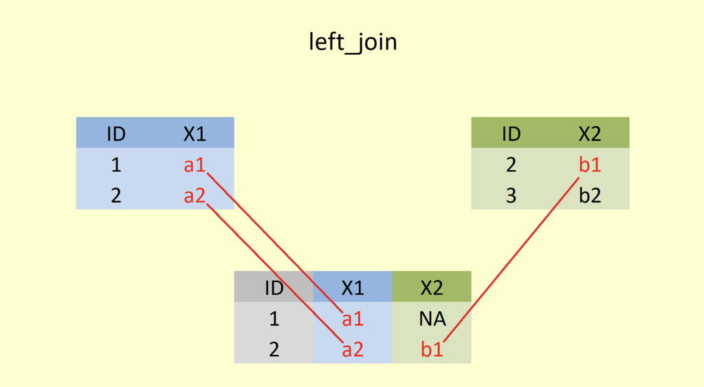

Figure 1. Simple example of left_join and output.

## left_join(x = table1, y = table2)

All the rows and columns from first referenced table are all kept. Then all information from the second referenced table is then carried into the first table if there is a match on the join key. This is considered a mutating join because you are adding a new column to a base dataset.

.tiny[

```r
joined_table1 <- left_join(superheroes, publishers)
joined_table1
```

```
## # A tibble: 7 × 5
##   name     alignment gender publisher         yr_founded
##   <chr>    <chr>     <chr>  <chr>                  <dbl>
## 1 Magneto  bad       male   Marvel                  1939
## 2 Storm    good      female Marvel                  1939
## 3 Mystique bad       female Marvel                  1939
## 4 Batman   good      male   DC                      1934
## 5 Joker    bad       male   DC                      1934
## 6 Catwoman bad       female DC                      1934
## 7 Hellboy  good      male   Dark Horse Comics         NA
```

]

## inner_join(x = table1, y = table2)

inner_join() returns (1) data rows from the first table if and only if there is a match on the second table on the join key and (2) all columns or variables from the first table. Similar to left_join, columns from the second table is added. Again, this is a mutating join because we are adding variable(s) to the base (first) table.

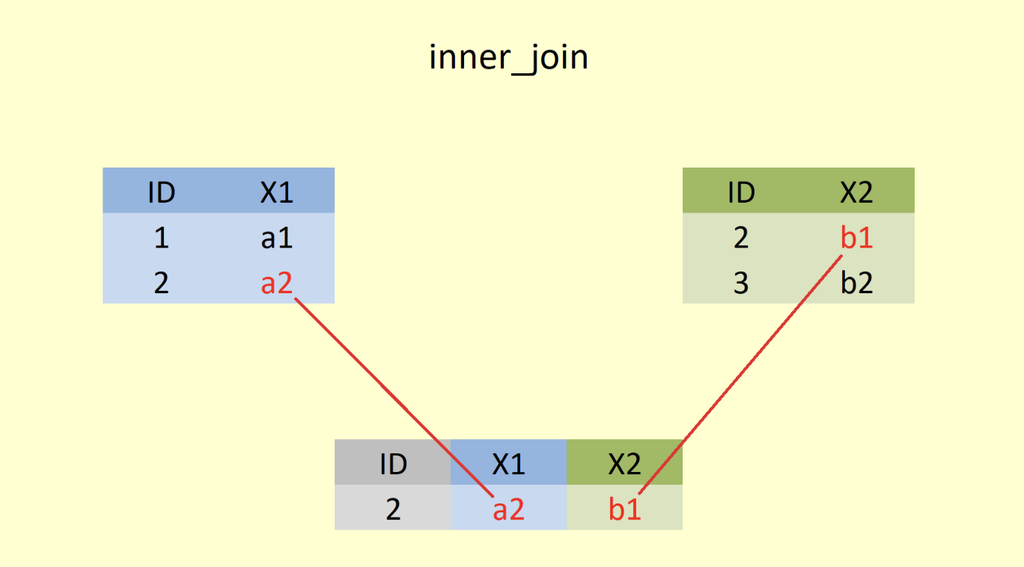

### inner_join(x = table1, y = table2)

inner_join() returns (1) data rows from the first table if and only if there is a match on the second table on the join key and (2) all columns or variables from the first table. Similar to left_join, columns from the second table is added. Again, this is a mutating join because we are adding variable(s) to the base (first) table.

Notice how the row with Hellboy is no longer present? That is because ‘Dark Horse Comics’ does not exist as one of the publishers within the publisher table. Hellboy doesn’t have a match on the second table, so it is not included.

.tiny[

```r
joined_table2 <- inner_join(superheroes, publishers)
joined_table2
```

```
## # A tibble: 6 × 5
##   name     alignment gender publisher yr_founded
##   <chr>    <chr>     <chr>  <chr>          <dbl>
## 1 Magneto  bad       male   Marvel          1939
## 2 Storm    good      female Marvel          1939
## 3 Mystique bad       female Marvel          1939
## 4 Batman   good      male   DC              1934
## 5 Joker    bad       male   DC              1934
## 6 Catwoman bad       female DC              1934
```

]

## semi_join(x = table1, y = table2)

Return all rows from table1 where there are matching values in table2, but nothing is added from the second table (keeping just columns from table1).

A semi join differs from an inner join because nothing is added from the second table (table2). This is a filtering join (not mutating join). You may think of semi_join() as filtering rows from table1 if and only if they have a match on table2 via a join key.

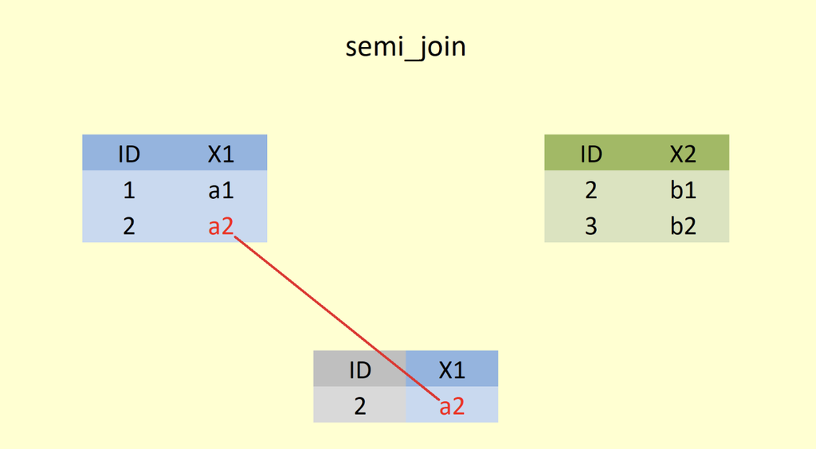

Figure 3. Simple example of semi_join and output.

## semi_join(x = table1, y = table2)

Return all rows from table1 where there are matching values in table2, but nothing is added from the second table (keeping just columns from table1).

A semi join differs from an inner join because nothing is added from the second table (table2). This is a filtering join (not mutating join). You may think of semi_join() as filtering rows from table1 if and only if they have a match on table2 via a join key.

.tiny[

```r
joined_table3 <- semi_join(superheroes, publishers)
joined_table3
```

```
## # A tibble: 6 × 4
##   name     alignment gender publisher
##   <chr>    <chr>     <chr>  <chr>
## 1 Magneto  bad       male   Marvel
## 2 Storm    good      female Marvel
## 3 Mystique bad       female Marvel
## 4 Batman   good      male   DC
## 5 Joker    bad       male   DC
## 6 Catwoman bad       female DC
```

]

## anti_join(x = table1, y =table2)

Return all rows from table1 that **does not have a match** with table2 via a join key, keeping just columns from table1. This is a filtering join (not create a new column).

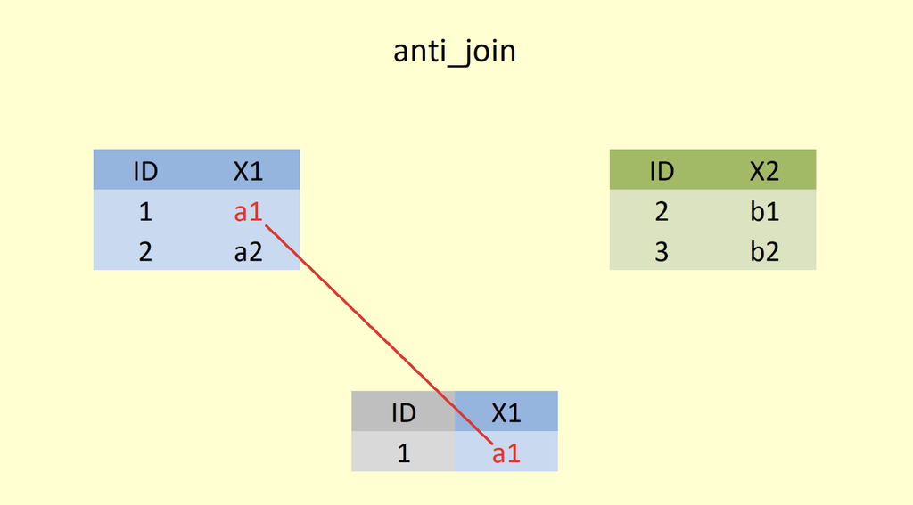

Figure 4. Simple example of anti_join and output.

## anti_join(x = table1, y = table2)

Return all rows from table1 that **does not have a match** with table2 via a join key, keeping just columns from table1. This is a filtering join (not create a new column).

```r
anti_join(superheroes, publishers)
```

```
## # A tibble: 1 × 4
##   name    alignment gender publisher
##   <chr>   <chr>     <chr>  <chr>
## 1 Hellboy good      male   Dark Horse Comics
```

## full_join(x = table1, y = table2)

Returns all columns and rows from table1 and table2. Often times, it actually doesn’t produce any meaningful results unless used in extremely specific circumstances (beyond the scope of this course).

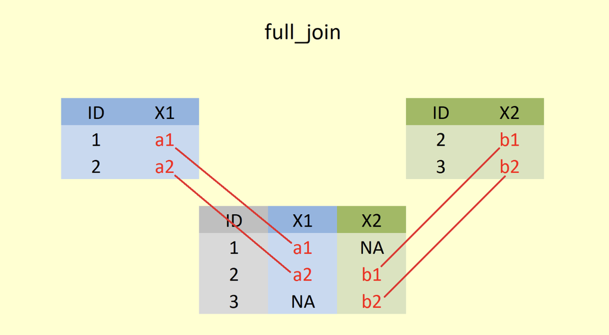

Figure 5. Simple example of full_join and output.

## full_join(x = table1, y = table2)

Returns all columns and rows from table1 and table2. Often times, it actually doesn’t produce any meaningful results unless used in extremely specific circumstances (beyond the scope of this course).

```r
full_join(superheroes, publishers)
```

```
## # A tibble: 8 × 5
##   name     alignment gender publisher         yr_founded
##   <chr>    <chr>     <chr>  <chr>                  <dbl>
## 1 Magneto  bad       male   Marvel                  1939
## 2 Storm    good      female Marvel                  1939
## 3 Mystique bad       female Marvel                  1939
## 4 Batman   good      male   DC                      1934
## 5 Joker    bad       male   DC                      1934
## 6 Catwoman bad       female DC                      1934
## 7 Hellboy  good      male   Dark Horse Comics         NA
## 8 <NA>     <NA>      <NA>   Image                   1992
```

## Forcing Join

There are times when the tables in your R environment share a join key but have different variable or column names (i.e., this time, while it is called publisher in superheroes_v2, it is now called company in publishers_v2). Now, let us work with superheroes_v2 and publishers_v2:

```r
superheroes_v2 <- tibble::tribble(
       ~name, ~alignment,  ~gender,          ~publisher,
   "Magneto",      "bad",   "male",            "Marvel",
     "Storm",     "good", "female",            "Marvel",
  "Mystique",      "bad", "female",            "Marvel",
    "Batman",     "good",   "male",                "DC",
     "Joker",      "bad",   "male",                "DC",
  "Catwoman",      "bad", "female",                "DC",
   "Hellboy",     "good",   "male", "Dark Horse Comics"
  )

publishers_v2 <- tibble::tribble(
  ~company, ~yr_founded,
        "DC",       1934,
    "Marvel",       1939,
     "Image",       1992
  )
```

## Let us see error produced by R when attempting to join those two

```r
left_join(superheroes_v2, publishers_v2)
```

```
## Error in `left_join()`:
## ! `by` must be supplied when `x` and `y` have no common variables.
## ℹ Use `cross_join()` to perform a cross-join.
```

## Dealing with join keys with different names?

Method 1: Rename to make them common.

In the example below, `publishers_v2`’s **company** variable is renamed to publisher using rename(). The resulting data is saved as `publishers_v3`. Then we use `publishers_v3` within the `left_join()`. .tiny[

```r
publishers_v3 <- publishers_v2 |>
  rename(publisher = company)

left_join(superheroes_v2, publishers_v3)
```

```
## # A tibble: 7 × 5
##   name     alignment gender publisher         yr_founded
##   <chr>    <chr>     <chr>  <chr>                  <dbl>
## 1 Magneto  bad       male   Marvel                  1939
## 2 Storm    good      female Marvel                  1939
## 3 Mystique bad       female Marvel                  1939
## 4 Batman   good      male   DC                      1934
## 5 Joker    bad       male   DC                      1934
## 6 Catwoman bad       female DC                      1934
## 7 Hellboy  good      male   Dark Horse Comics         NA
```

]

## Dealing with join keys with different names?

Method 2: Manual specification method using `join_by()`

You are telling R below that the two tables have a common key but named differently. You are telling R to treat superheroes_v2’s publisher and publishers_v2’s company as the equivalent join keys. .tiny[

```r
left_join(superheroes_v2, publishers_v2, join_by(publisher == company))
```

```
## # A tibble: 7 × 5
##   name     alignment gender publisher         yr_founded
##   <chr>    <chr>     <chr>  <chr>                  <dbl>
## 1 Magneto  bad       male   Marvel                  1939
## 2 Storm    good      female Marvel                  1939
## 3 Mystique bad       female Marvel                  1939
## 4 Batman   good      male   DC                      1934
## 5 Joker    bad       male   DC                      1934
## 6 Catwoman bad       female DC                      1934
## 7 Hellboy  good      male   Dark Horse Comics         NA
```

]

## Here’s an example that requires two join keys: continent and year

Suppose we are interested in combining pop_df and life_df:

.pull-left[ .tiny[

```r
pop_df <- read_rds("https://github.com/jmtfeliciano/teachingdata/raw/refs/heads/main/pop_df.rds")
head(pop_df)
```

```
## # A tibble: 6 × 3
## # Groups:   continent [2]
##   continent  year total_population
##   <fct>     <int>            <dbl>
## 1 Africa     1997        743832984
## 2 Africa     2002        833723916
## 3 Africa     2007        929539692
## 4 Americas   1997        796900410
## 5 Americas   2002        849772762
## 6 Americas   2007        898871184
```

] ]

.pull-right[ .tiny[

```r
life_df <- read_rds("https://github.com/jmtfeliciano/teachingdata/raw/refs/heads/main/life_df.rds")
head(life_df)
```

```
## # A tibble: 6 × 3
##   continent  year mean_life_expectancy
##   <fct>     <int>                <dbl>
## 1 Africa     1997                 53.6
## 2 Africa     2002                 53.3
## 3 Africa     2007                 54.8
## 4 Americas   1997                 71.2
## 5 Americas   2002                 72.4
## 6 Americas   2007                 73.6
```

] ]

The join requires two join keys: continent, year

## Joining pop_df and life_df: multiple join keys

.pull-left[ .extra-tiny[

```r
# Method 1: add multiple keys inside join_by()
left_join(pop_df, life_df,
          join_by(continent, year))
```

```
## # A tibble: 12 × 4
## # Groups:   continent [4]
##    continent  year total_population mean_life_expectancy
##    <fct>     <int>            <dbl>                <dbl>
##  1 Africa     1997        743832984                 53.6
##  2 Africa     2002        833723916                 53.3
##  3 Africa     2007        929539692                 54.8
##  4 Americas   1997        796900410                 71.2
##  5 Americas   2002        849772762                 72.4
##  6 Americas   2007        898871184                 73.6
##  7 Asia       1997       3383285500                 NA
##  8 Asia       2002       3601802203                 NA
##  9 Asia       2007       3811953827                 NA
## 10 Oceania    1997         22241430                 78.2
## 11 Oceania    2002         23454829                 79.7
## 12 Oceania    2007         24549947                 80.7
```

] ]

.pull-right[ .extra-tiny[

```r
# Method 2: let R do the work for you
left_join(pop_df, life_df)
```

```
## # A tibble: 12 × 4
## # Groups:   continent [4]
##    continent  year total_population mean_life_expectancy
##    <fct>     <int>            <dbl>                <dbl>
##  1 Africa     1997        743832984                 53.6
##  2 Africa     2002        833723916                 53.3
##  3 Africa     2007        929539692                 54.8
##  4 Americas   1997        796900410                 71.2
##  5 Americas   2002        849772762                 72.4
##  6 Americas   2007        898871184                 73.6
##  7 Asia       1997       3383285500                 NA
##  8 Asia       2002       3601802203                 NA
##  9 Asia       2007       3811953827                 NA
## 10 Oceania    1997         22241430                 78.2
## 11 Oceania    2002         23454829                 79.7
## 12 Oceania    2007         24549947                 80.7
```

] ]

## Download Exercise7.qmd from Canvas and open in R. You have 20 mins to complete this. Then I will go over solution.